# Journal Club FAO Scatterplot

Ben

1/28/2021

## Objective

- Import and clean FAO data on yield, cropland area, and population
- Replicate/modernize Ewers (2009) scatterplot using data from 1999-20182

#### Read in Data

23 “Staple Crops” were selected according to Ewers 2009, with yield, acreage, and population data imported for 1999-2018.

Below analyses are currently for 1999-2018

The table below shows the values for the change in per capita cropland area and yield for the same 23 staple crops analyzed in Ewers 2009. In this case, these “log.delta.area” represent the Y-axis of Fig. 2 from that paper, with “log.delta.yield” as the X. Notably, some of the Y values are quite extreme comparatively, with nearly twice as much cropland area per capita lost as compare to the 1979-1999 period shown in Ewers. This is in line with overall cropland area estimates that Rob showed though. “Dir” here just shows whether each value is positive or negative, though it was useful to look at overall relationships.

```r
combined_data <- left_join(pc.area.dif,kcal.yield.dif)
scroll_box(
  kable(combined_data,
        caption = "Per capita changes in cropland area and yield for 23 staple crops (1999:2018)") %>% kable_styling(),
  height = "700px",
  width = "800px")
```

Per capita changes in cropland area and yield for 23 staple crops (1999:2018)

| Area | log.delta.area | dir.area | log.delta.yield | dir.yield |
| --- | --- | --- | --- | --- |
| Afghanistan | -0.8520037 | neg | 0.3686198 | pos |
| Albania | -0.1046801 | neg | 0.4456699 | pos |
| Algeria | 0.2824474 | pos | 0.8101197 | pos |
| Angola | 0.4533653 | pos | 0.0991101 | pos |
| Antigua and Barbuda | 0.6115272 | pos | -0.1040486 | neg |
| Argentina | 0.2158483 | pos | 0.0786114 | pos |
| Armenia | -0.1808729 | neg | 0.3097684 | pos |
| Australia | -0.2784407 | neg | 0.0869495 | pos |
| Austria | -0.1216502 | neg | -0.0752522 | neg |
| Azerbaijan | 0.4706306 | pos | 0.4420345 | pos |
| Bahamas | 0.1408653 | pos | 0.7504215 | pos |
| Bahrain | -2.0975913 | neg | 0.6975958 | pos |
| Bangladesh | -0.1824766 | neg | 0.5762870 | pos |
| Barbados | -0.8814959 | neg | 0.0854940 | pos |
| Belarus | -0.1748873 | neg | 0.6173965 | pos |
| Belize | -0.0248168 | neg | 0.0899112 | pos |
| Benin | 0.1071318 | pos | 0.3024642 | pos |
| Bhutan | -1.2450249 | neg | 0.3563462 | pos |
| Bolivia (Plurinational State of) | 0.2359450 | pos | 0.2759153 | pos |
| Bosnia and Herzegovina | 0.0031238 | pos | 0.2323099 | pos |
| Botswana | 0.0947254 | pos | 0.6050744 | pos |
| Brazil | 0.3896259 | pos | 0.3990656 | pos |
| Brunei Darussalam | -1.5988319 | neg | 0.4398601 | pos |
| Bulgaria | 0.1717522 | pos | 0.5167697 | pos |
| Burkina Faso | -0.1398551 | neg | 0.1391695 | pos |
| Burundi | -0.2629530 | neg | 0.0024220 | pos |
| CÃ´te d’Ivoire | 0.2665930 | pos | -0.0865013 | neg |
| Cabo Verde | -0.2480839 | neg | 0.1263983 | pos |
| Cambodia | 0.2495971 | pos | 0.1995374 | pos |
| Cameroon | 0.4915292 | pos | -0.1159999 | neg |

[output cut: 163 more lines]

In this case, the yield values are quite similar to those from Ewers. It’s possible that kcal yield per hectare for these staples hasn’t changed much since 1999, but let’s visualize these together in a format similar to Ewers Figure 2.

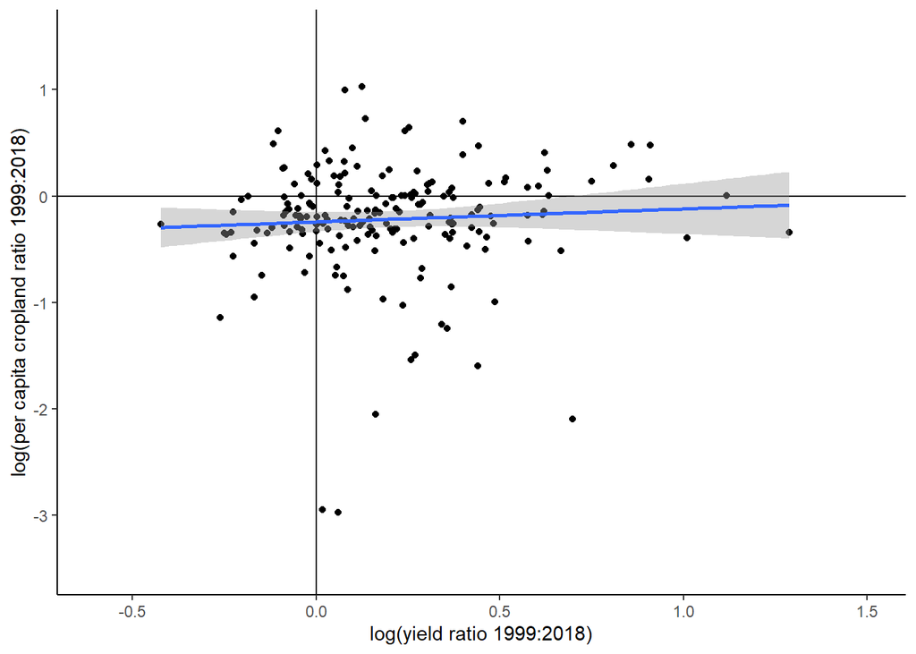

```r
ggplot(data = combined_data, mapping = aes(x = log.delta.yield, y = log.delta.area)) + theme_classic() +
         geom_point() + geom_hline(yintercept = 0) + geom_vline(xintercept = 0) + geom_smooth(method = "lm") + xlim(-.6,1.5)+
  ylim(-3.5,1.5) + labs(x = "log(yield ratio 1999:2018)", y = "log(per capita cropland ratio 1999:2018)")
```

The models from Ewers were pretty simple, so we can look at the relationship too.

```r
model <- lm(log.delta.area ~ log.delta.yield, data = combined_data)
summary(model)
```

```
##
## Call:
## lm(formula = log.delta.area ~ log.delta.yield, data = combined_data)
##
## Residuals:
##      Min       1Q   Median       3Q      Max
## -2.73698 -0.12289  0.04876  0.24980  1.25591
##
## Coefficients:
##                 Estimate Std. Error t value Pr(>|t|)
## (Intercept)     -0.24264    0.04682  -5.182 5.55e-07 ***
## log.delta.yield  0.12256    0.14126   0.868    0.387
## ---
## Signif. codes:  0 '***' 0.001 '**' 0.01 '*' 0.05 '.' 0.1 ' ' 1
##
## Residual standard error: 0.5285 on 191 degrees of freedom
## Multiple R-squared:  0.003926,   Adjusted R-squared:  -0.001289
## F-statistic: 0.7528 on 1 and 191 DF,  p-value: 0.3867
```

The coefficient here is 0.122, slightly positive but not significant (p = 0.387). Again, this is only from 1999-2018, and on the 23 “staple” crops, so it doesn’t mean we won’t find a sparing effect later. When we break these down by a variety of other factors we may be able to gain more insight into where sparing may occur.

### Visualizing more dates

I’ve written a function to be able to plot these similar figures across different time points, below are a few examples!

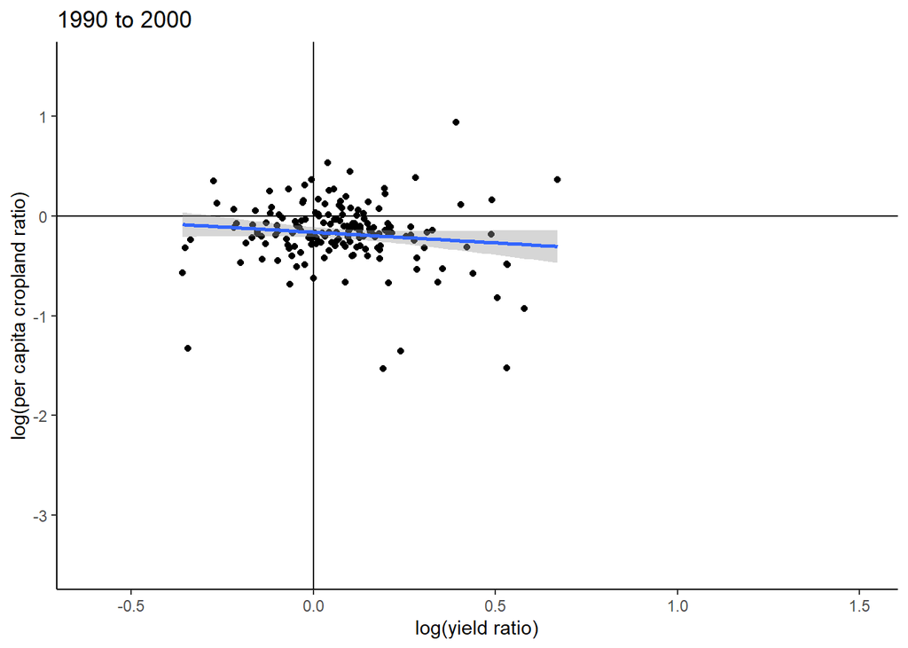

```r
# Same data but includes 1990-2018 data
staple_data <- staple_data <- read.csv("../data/fao_staples.csv", sep = ",", header = T)
pop_data <- read.csv("../data/fao_pop.csv", sep = ",", header = T)

# 1990 to 2000
ewers_data(staple = staple_data, pop = pop_data, start = 1990, end = 2000)
```

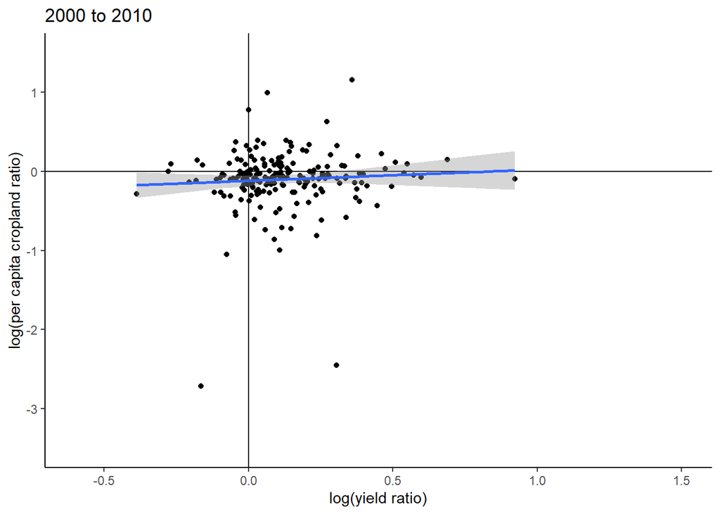

```r
# 2000 to 2010
ewers_data(staple = staple_data, pop = pop_data, start = 2000, end = 2010)
```

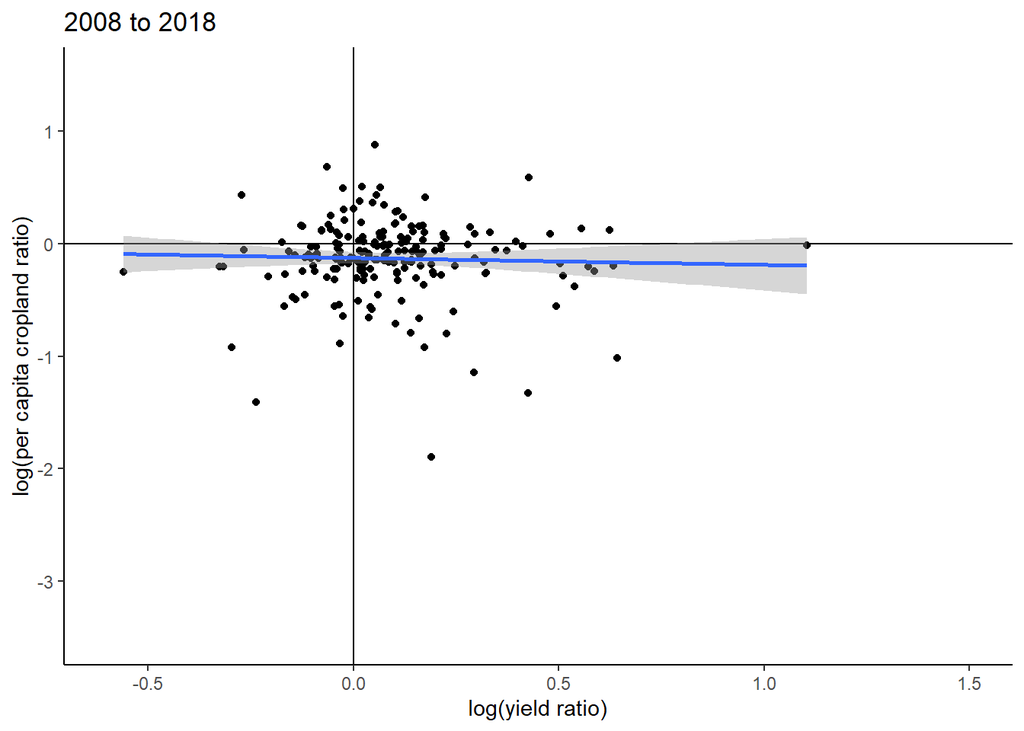

```r
# 2008 to 2018
ewers_data(staple = staple_data, pop = pop_data, start = 2008, end = 2018)
```

Just did 10 year periods here, since the difference values change size depending on the total number of years compared (expectedly, as trends continue over time). We can easily adjust periods to fit times of interest, and compare decades or some other unit.

My guess is there are likely several agroecological factors we could look into that may explain some of the variance among countries.